# Code du projet

Groupe 21

2025-02-01

# Importation des données

```r
base <- readRDS(gzfile("base_REPRO_ENSAI_VarX_VarY_Respi2.RData"))
```

# Etape 1 : vérification des données

## Type de variables

```r
# liste des types de variables
unique(sapply(base, class))
```

```
## [1] "character" "factor"    "numeric"
```

```r
# liste des variables par types

# type de chaque colonne
types <- sapply(base, class)

# noms des colonnes par type
variables_par_type <- split(names(types), types)

# variables par type
variables_par_type
```

```
## $character
## [1] "CODE_ELEVAGE"
##
## $factor
##   [1] "MAT_TxPo"                         "MAT_EterPo"
##   [3] "X17x3_DIAPLavt7J"                 "X17x3_DIAMAY"
##   [5] "X17x3_CONSMB"                     "X17x3_CMAMB"
##   [7] "X17x3_MAMB"                       "X17x4_ABBCOM_TR"
##   [9] "X17x4_ABBMA_TR"                   "X17x4_ABBTLOC_TR"
##  [11] "X17x4_ABBFI_TR"                   "X17x4_ABB_PNS"
##  [13] "X17x4_ABBART_PNS"                 "X20x1_ECOUVU"
##  [15] "X20x2_ABB_VG"                     "X20x2_ABBAVOR_VG"
##  [17] "X20x2_ABBTLOC_VG"                 "X20x2_ABBDIA_VG"
##  [19] "X20x2_ABB_Ve"                     "X20x2_ABBTLOC_Ve"
##  [21] "X21x1_PBCHA"                      "X21x2_ABB_QU"
```

[output cut: 198 more lines]

On voit bien qu’hormis l’identifiant (CODE_ELEVAGE = character), toutes les variabls sont de type Factor ou Numeric

# Données manquantes

## Pourcentage de données manquantes par variables

```r
# Calcul du pourcentage de données manquantes par variable
pourcentage_manquants <- round(colSums(is.na(base)) / nrow(base) * 100,0)

# Transformons en dataframe pour une présentation claire
var_na_percent <- data.frame(
  variable = names(pourcentage_manquants),
  pourcentage = pourcentage_manquants
)

# Rangeons par ordre décroissant des pourcentages
var_na_percent <- var_na_percent[order(-var_na_percent$pourcentage), ]
```

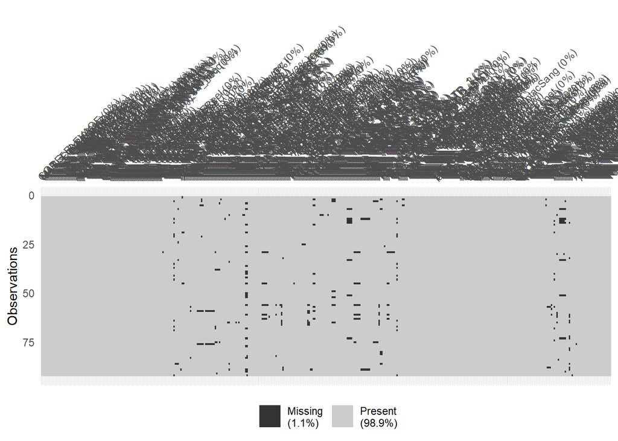

```r
# Visualiser les données manquantes
library(visdat)

# Heatmap des données manquantes
vis_miss(base)
```

## Variables avec plus de 15 % de NA

```r
# variables avec >15% de données manquantes et leurs pourcentages
var_na_percent_plus_15 <- var_na_percent[var_na_percent$pourcentage > 15,]

# Résultat
var_na_percent_plus_15
```

```
##                                      variable pourcentage
## X15x1x2_DEPI1_GEST_rec X15x1x2_DEPI1_GEST_rec          26
## X15x1x2_DEPI1_MAT_rec   X15x1x2_DEPI1_MAT_rec          24
```

On va continuer avec les variables ayant moins de 15 % de NA

```r
# variables avec <=15% de données manquantes
variables_conservees <- var_na_percent$variable[var_na_percent$pourcentage <= 15]

# sélectionner uniquement ces variables
base2 <- base[, variables_conservees]

# Dimensions de la nouvelle base
dim(base2)
```

```
## [1]  92 412
```

# Vérification des modalités

```r
# Tableau récapitulatif
recap_modalites <- data.frame(
  Variable = character(),
  Nb_Modalites = integer(),
  Frequence_Max = numeric(),
  Frequence_Min = numeric(),
  stringsAsFactors = FALSE
)

# Boucle pour analyser chaque variable de type factor
for (var in names(base2)) {
  # Tableau de fréquences pour la variable
  freq_table <- table(base2[[var]])

  # Ajouter les informations au tableau récapitulatif
  recap_modalites <- rbind(
    recap_modalites,
    data.frame(
      Variable = var,
      Nb_Modalites = length(freq_table),
      Frequence_Max = round(max(freq_table) / sum(freq_table) * 100, 0), # fréquence max des modalités en %
      Frequence_Min = round(min(freq_table) / sum(freq_table) * 100, 2)  # fréquence min des modalités en %
    )
  )
}

# Trier le tableau par nombre de modalités
recap_modalites <- recap_modalites[order(-recap_modalites$Frequence_Max), ]
```

## Variables déséquilibrées (avec 1 modalité >= 85% répondants)

```r
# variables ayant une modalité avec une fréquence >= 85%
variables_desequilibrees <- recap_modalites$Variable[recap_modalites$Frequence_Max >= 85]

variables_desequilibrees
```

```
##  [1] "T04_MAT_NoteIndTrAbc_2"     "T04_MAT_NoteIndTrCongM_2"
##  [3] "A03_TxPosTSi"               "A03_TxPosTOt"
##  [5] "T04_MAT_NoteIndTrMma"       "A03_TxPosTAc"
##  [7] "T04_MAT_NoteIndTrCongM_1"   "NoteIndPorteeDiarr_4_freq"
##  [9] "A03_TxPosTAs"               "A03_MyTAs"
## [11] "A03_MdTAs"                  "T04_MAT_NoteIndTrCongM_0"
## [13] "T04_MAT_NoteIndTrCongM_BIN" "T08_VG_NoteIndTrGale"
## [15] "A03_sdTTs"                  "T04_MAT_NoteIndTrAbc_1"
## [17] "T04_MAT_NoteIndTrAbc_0"     "T04_MAT_NoteIndTrAbc_BIN"
## [19] "NoteIndPorteeDiarr_3_freq"  "A03_TxPosTTs"
## [21] "NoteIndPorteeDiarr_2_freq"  "X14x1_MPH_1_rec"
## [23] "T02_MAT_CourExt"            "T21_Elev_Cot"
## [25] "Mat_Bat_Trou_Ouv_Fenet"     "X01x1_PPHBTEL"
## [27] "X17x3_SEVPRE"
```

Nous avons donc 27 variables avec avec 1 modalité >= 85% répondants.

Nous allons poursuivre sans elles.

```r
# Créons base3 en excluant ces variables
base3 <- base2[, !(names(base2) %in% variables_desequilibrees)]

dim(base3)
```

```
## [1]  92 385
```

## Modalité avec <=15% de répondants

```r
# On va restreindre le travail aux variables de types facteur
base4 <- Filter(is.factor, base3)

# Tableau récapitulatif
recap_modalite_2 <- data.frame(
  Variable = character(),
  Nb_Modalites = integer(),
  Frequence_Max = numeric(),
  Frequence_Min = numeric(),
  stringsAsFactors = FALSE
)

# Boucle pour analyser chaque variable de type factor
for (var in names(base4)) {
  # Tableau de fréquences pour la variable
  freq_table <- table(base4[[var]])

  # Ajouter les informations au tableau récapitulatif
  recap_modalite_2 <- rbind(
    recap_modalite_2,
    data.frame(
      Variable = var,
      Nb_Modalites = length(freq_table),
      Frequence_Max = round(max(freq_table) / sum(freq_table) * 100, 2), # fréquence max des modalités en %
      Frequence_Min = round(min(freq_table) / sum(freq_table) * 100, 2)  # fréquence min des modalités en %
    )
  )
}

# Trier le tableau par nombre de modalités
recap_modalite_2 <- recap_modalite_2[order(-recap_modalite_2$Frequence_Max), ]

# Ajouter une colonne pour indiquer si une modalité ≤ 15% existe
recap_modalite_2$Existence_Modalite_Inf_15 <- recap_modalite_2$Frequence_Min <= 15

table(recap_modalite_2$Existence_Modalite_Inf_15)
```

```
##
## FALSE
##   319
```

Il n’y a aucune variable avec des modalités inférieures à 15 %. On va donc conserver pour la suite toutes ces variables catégorielles

```r
# Identification des variables numériques avec faible variabilité
base_numeric <- Filter(is.numeric, base3)
cv_variables=sapply(base_numeric, function(x) sd(x,na.rm=T)*100/mean(x, na.rm=T))

resume=data.frame(Variable=names(base_numeric),coeff_variation=cv_variables, ecart_type=sapply(base_numeric,sd))
resume_tried=resume[order(resume$coeff_variation),]
head(resume_tried)
```

```
##                                            Variable coeff_variation ecart_type
## NoteIndPorteeDiarr_1_freq NoteIndPorteeDiarr_1_freq        13.22056 12.4491877
## T05_NoteIndPorteeGriff0Nb T05_NoteIndPorteeGriff0Nb        16.53616 14.8543017
## T05_NoteIndPorteeProp0Nb   T05_NoteIndPorteeProp0Nb        18.35841 16.5737977
## T05_NoteIndPorteeDiarr       T05_NoteIndPorteeDiarr        25.98171  8.8469794
## T03_MAT_AgePo                         T03_MAT_AgePo        26.16897  0.8049803
## A03_NbEspCo                             A03_NbEspCo        31.52648  0.4968847
```

On constate que quasiment toutes ces variables numériques sont assez dispersées. On va donc les conserver pour la suite

# Etape 2 : Etude du lien entre les variables décrivant les signes cliniques respiratoires

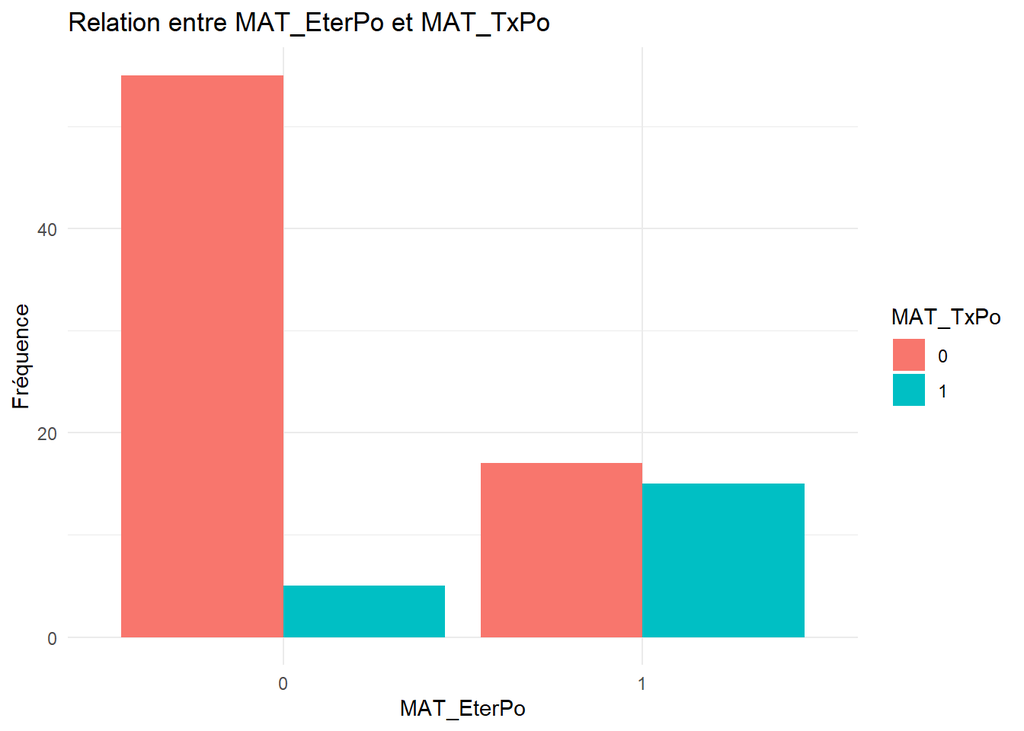

```r
##Etude du lien entre les deux variables a_expliquer
library(ggplot2)
table_freq <- table(base3$MAT_TxPo, base3$MAT_EterPo)

# Transformer le tableau en data.frame pour ggplot
data_plot <- as.data.frame(table_freq)
colnames(data_plot) <- c("MAT_TxPo", "MAT_EterPo", "Freq")
ggplot(data_plot, aes(x = MAT_EterPo, y = Freq, fill = MAT_TxPo)) +
  geom_bar(stat = "identity", position = "dodge") +
  labs(
    title = "Relation entre MAT_EterPo et MAT_TxPo",
    x = "MAT_EterPo",
    y = "Fréquence",
    fill = "MAT_TxPo"
  ) +
  theme_minimal()
```

## Test de Khi 2

```r
## Test du chi-2 pour évaluer le lien

table_deux=table(base3$MAT_TxPo,base3$MAT_EterPo)##condition du test: chaque case>=5 observations

result_test=chisq.test(x=base3$MAT_TxPo,y=base3$MAT_EterPo)
```

La p-value du test est 6.2456763^{-5}.

On rejette donc au seuil de 20% l’hypothèse d’indépendance entre les 2 variables, elles ne sont donc pas indépendantes

```r
library(vcd)
result_test = assocstats(table_deux)##coeffcients V Cramer
```

Cette liaison est par ailleurs quantifiée par un V de Cramer de l’order de 44.5 %

## Clustering

```r
##K-modes
library(klaR)
data <- data.frame(
  MAT_TxPo=base3$MAT_TxPo,
  MAT_EterPo=base3$MAT_EterPo
)

# Clustering K-modes
cost_values=c()
for (K in 1:4) {
  model <- kmodes(data, modes = K)
  cost_values <- c(cost_values, sum(model$withindiff))
}
```

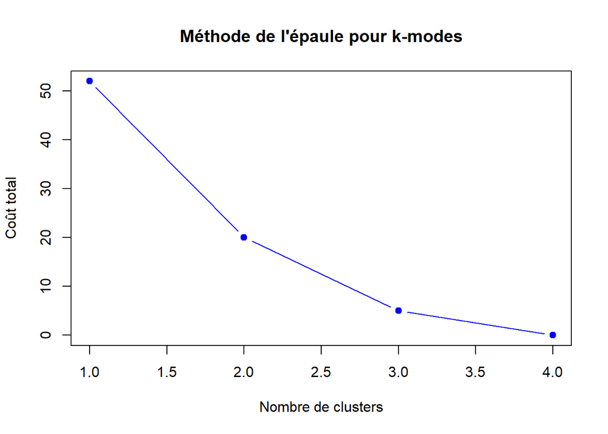

```r
# Tracer le coût en fonction du nombre de clusters
plot(1:4, cost_values, type = "b", pch = 19, col = "blue",
     xlab = "Nombre de clusters", ylab = "Coût total",
     main = "Méthode de l'épaule pour k-modes")
```

```r
result <- kmodes(data, modes = 2)

# Nouvelle variable basée sur les clusters
data$cluster <- as.factor(result$cluster)
```

### Interprétation

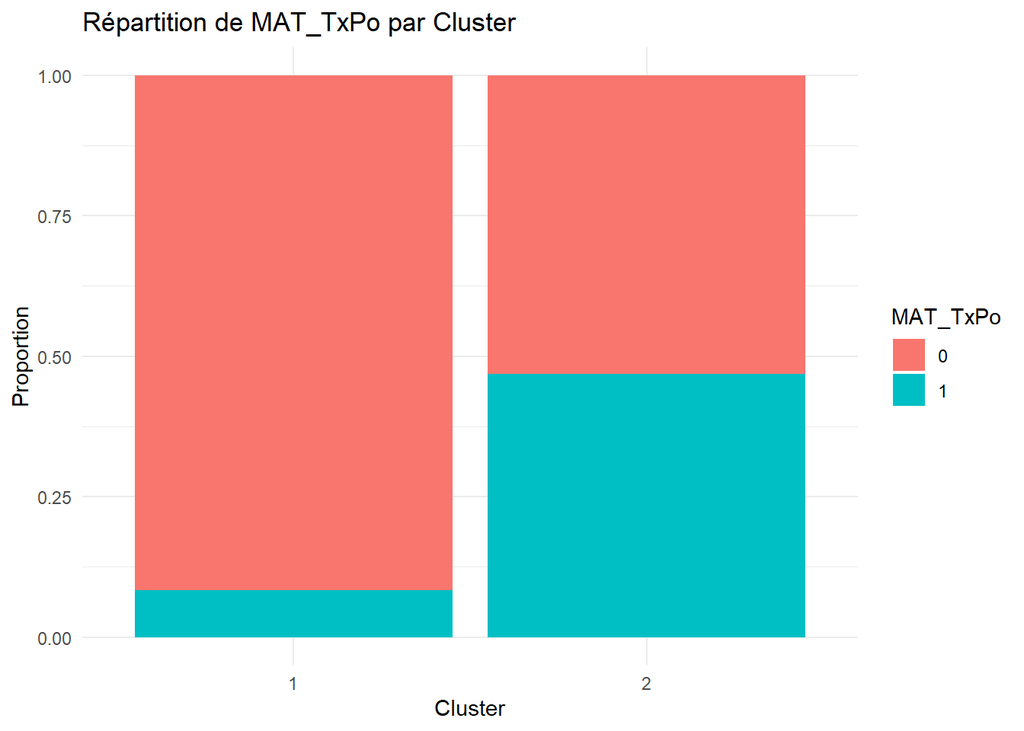

```r
library(ggplot2)
# Création du graphique
ggplot(data, aes(x = cluster, fill = MAT_TxPo)) +
  geom_bar(position = "fill") +
  labs(
    title = "Répartition de MAT_TxPo par Cluster",
    x = "Cluster",
    y = "Proportion"
  ) +
  theme_minimal()
```

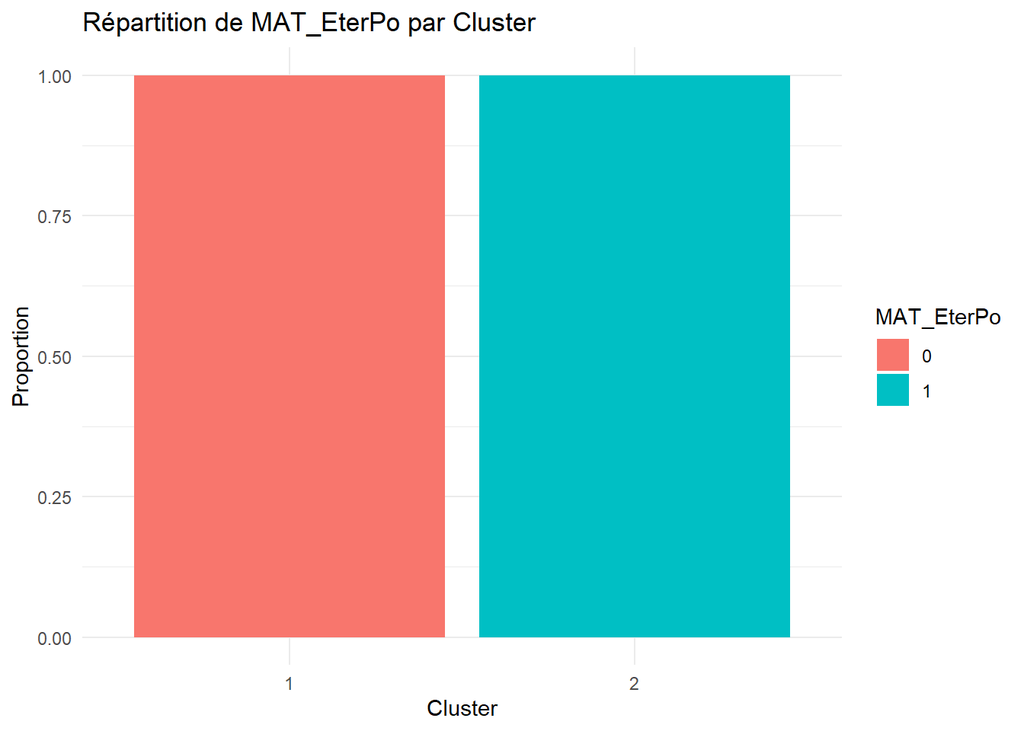

```r
# Diagramme pour MAT_EterPo
ggplot(data, aes(x = cluster, fill = MAT_EterPo)) +
  geom_bar(position = "fill") +
  labs(
    title = "Répartition de MAT_EterPo par Cluster",
    x = "Cluster",
    y = "Proportion"
  ) +
 theme_minimal()
```

##Réalisation d’une ACM avec les 2 variables à expliquer

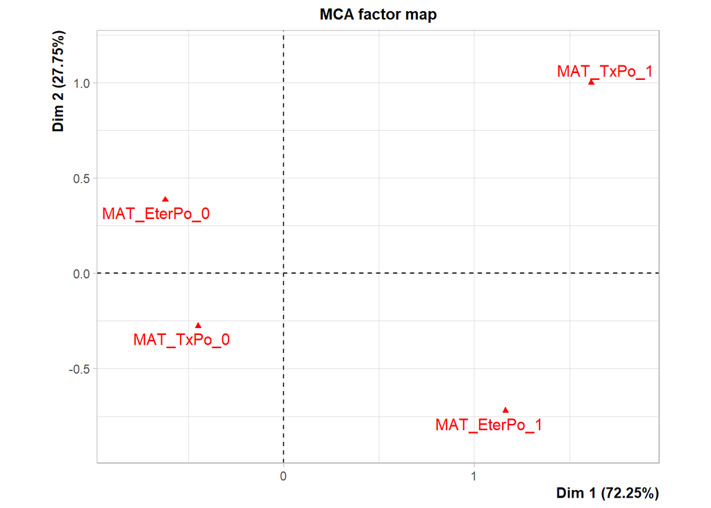

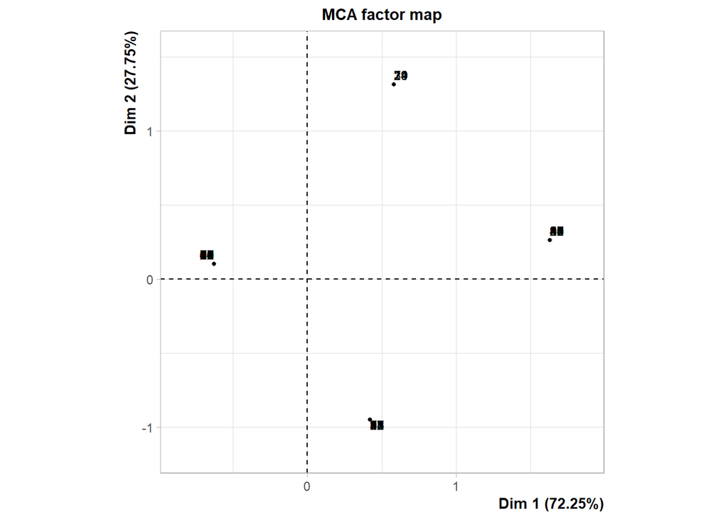

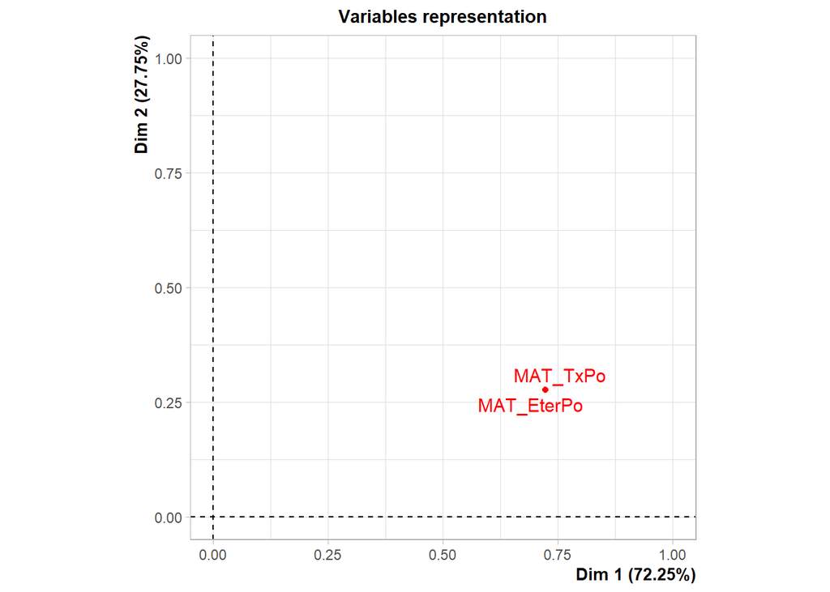

```r
##On se limite aux deux variables à expliquer
data_a_expliquer <- data.frame(
  'MAT_TxPo'=base3$MAT_TxPo,
  'MAT_EterPo'=base3$MAT_EterPo
)

library(FactoMineR)
acm_result <- MCA(data_a_expliquer, graph = TRUE)
```

```r
summary(acm_result)
```

```
##
## Call:
## MCA(X = data_a_expliquer, graph = TRUE)
##
##
## Eigenvalues
##                        Dim.1   Dim.2
## Variance               0.723   0.277
## % of var.             72.252  27.748
## Cumulative % of var.  72.252 100.000
##
## Individuals (the 10 first)
##                 Dim.1    ctr   cos2    Dim.2    ctr   cos2
## 1            | -0.629  0.595  0.975 |  0.102  0.040  0.025 |
## 2            |  0.584  0.512  0.165 |  1.314  6.762  0.835 |
## 3            |  0.421  0.267  0.165 | -0.948  3.522  0.835 |
## 4            |  1.633  4.013  0.975 |  0.264  0.273  0.025 |
## 5            |  1.633  4.013  0.975 |  0.264  0.273  0.025 |
## 6            | -0.629  0.595  0.975 |  0.102  0.040  0.025 |
## 7            |  0.421  0.267  0.165 | -0.948  3.522  0.835 |
## 8            |  1.633  4.013  0.975 |  0.264  0.273  0.025 |
## 9            | -0.629  0.595  0.975 |  0.102  0.040  0.025 |
## 10           | -0.629  0.595  0.975 |  0.102  0.040  0.025 |
##
## Categories
##                 Dim.1    ctr   cos2 v.test    Dim.2    ctr   cos2 v.test
## MAT_TxPo_0   | -0.448 10.870  0.723 -8.109 | -0.278 10.870  0.277 -5.025 |
## MAT_TxPo_1   |  1.613 39.130  0.723  8.109 |  0.999 39.130  0.277  5.025 |
## MAT_EterPo_0 | -0.621 17.391  0.723 -8.109 |  0.385 17.391  0.277  5.025 |
## MAT_EterPo_1 |  1.164 32.609  0.723  8.109 | -0.721 32.609  0.277 -5.025 |
##
## Categorical variables (eta2)
##                Dim.1 Dim.2
## MAT_TxPo     | 0.723 0.277 |
## MAT_EterPo   | 0.723 0.277 |
```

##Contributions des variables et coordonnées des individus

```r
# Contributions des variables aux axes
print(acm_result$var$contrib)
```

```
##                 Dim 1    Dim 2
## MAT_TxPo_0   10.86957 10.86957
## MAT_TxPo_1   39.13043 39.13043
## MAT_EterPo_0 17.39130 17.39130
## MAT_EterPo_1 32.60870 32.60870
```

```r
# Coordonnées des individus
coord_ind=acm_result$ind$coord
```

###CAH sur les coordonnées des individus sur les 2 axes

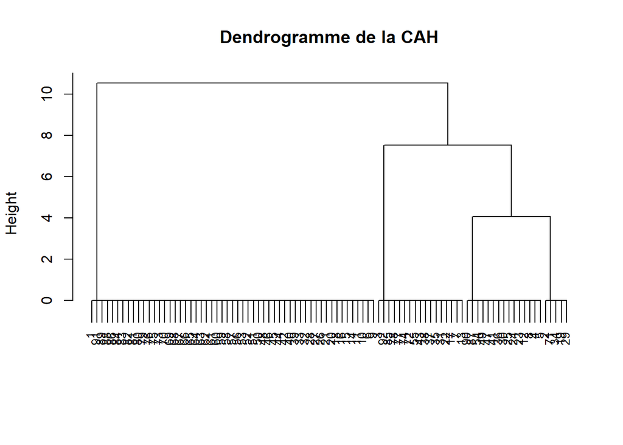

```r
individuals_coord=as.data.frame(acm_result$ind$coord)

# Matrice de distances
distance_matrix <- dist(individuals_coord)
# Classification ascendante hiérarchique
cah <- hclust(distance_matrix, method = "ward.D2")
# Visualiser le dendrogramme
plot(cah, main = "Dendrogramme de la CAH", xlab = "", sub = "", cex = 0.8)
```

#METHODE POUR DETERMINER LE NOMBRE OPTIMAL DE CLUSTER

```r
library(cluster)
library(factoextra)
```

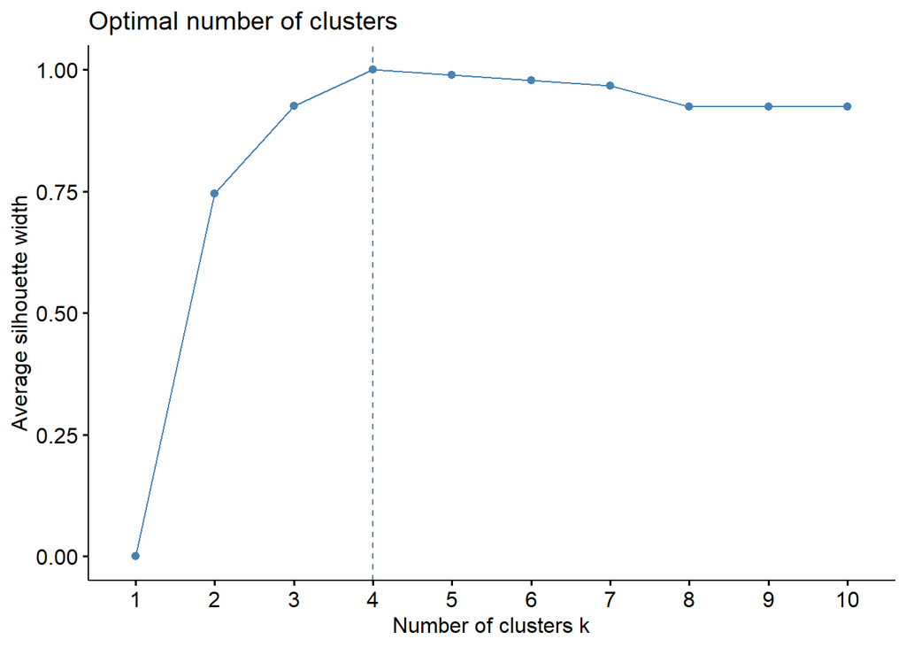

```r
coord_ind=acm_result$ind$coord
fviz_nbclust(coord_ind, FUN = hcut, method = "silhouette")
```

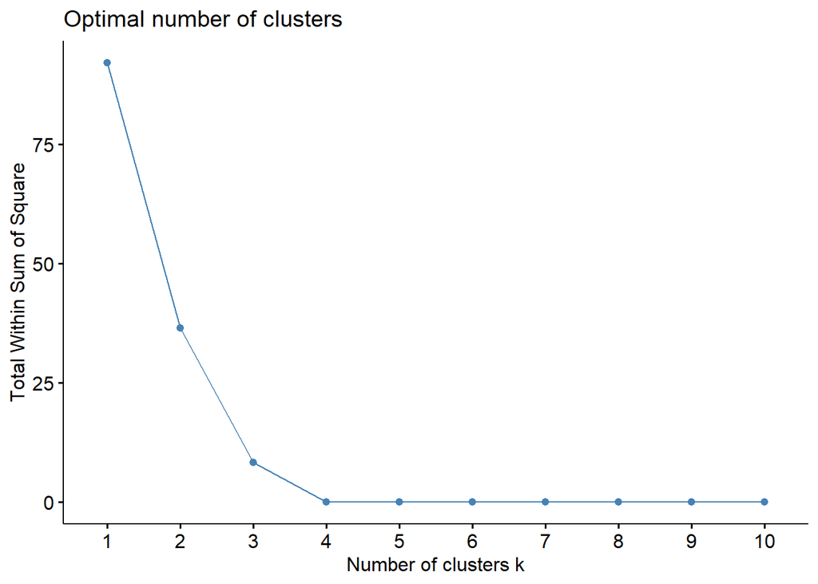

```r
fviz_nbclust(coord_ind, FUN = hcut, method = "wss")
```

## Création des clusters

```r
k <- 3
clusters <- cutree(cah, k = k)
data_a_expliquer$clusters <- as.factor(clusters)
```

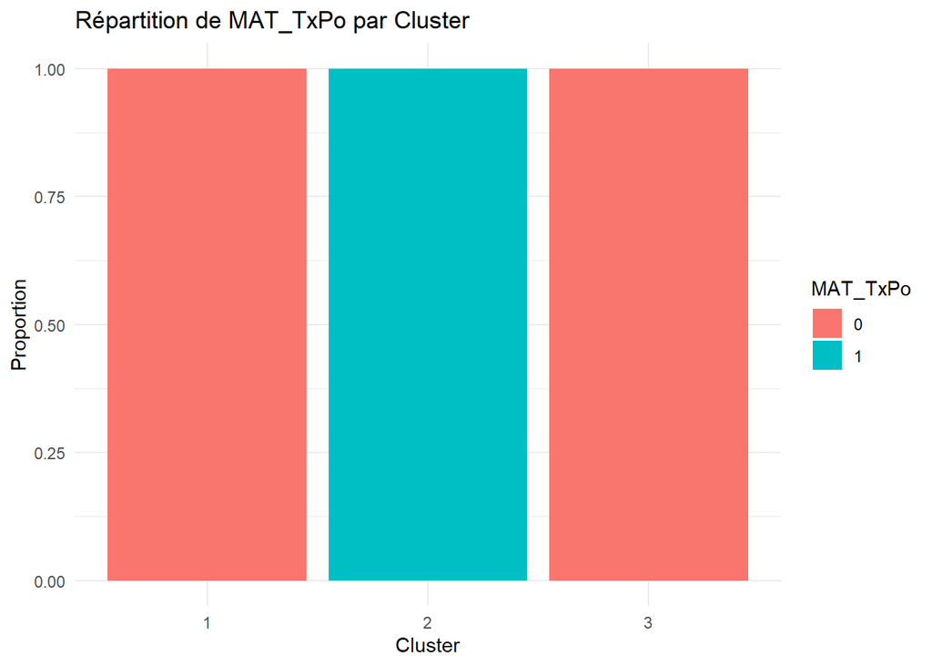

```r
ggplot(data_a_expliquer, aes(x = clusters, fill = MAT_TxPo)) +
  geom_bar(position = "fill") +
  labs(
    title = "Répartition de MAT_TxPo par Cluster",
    x = "Cluster",
    y = "Proportion"
  ) +
  theme_minimal()
```

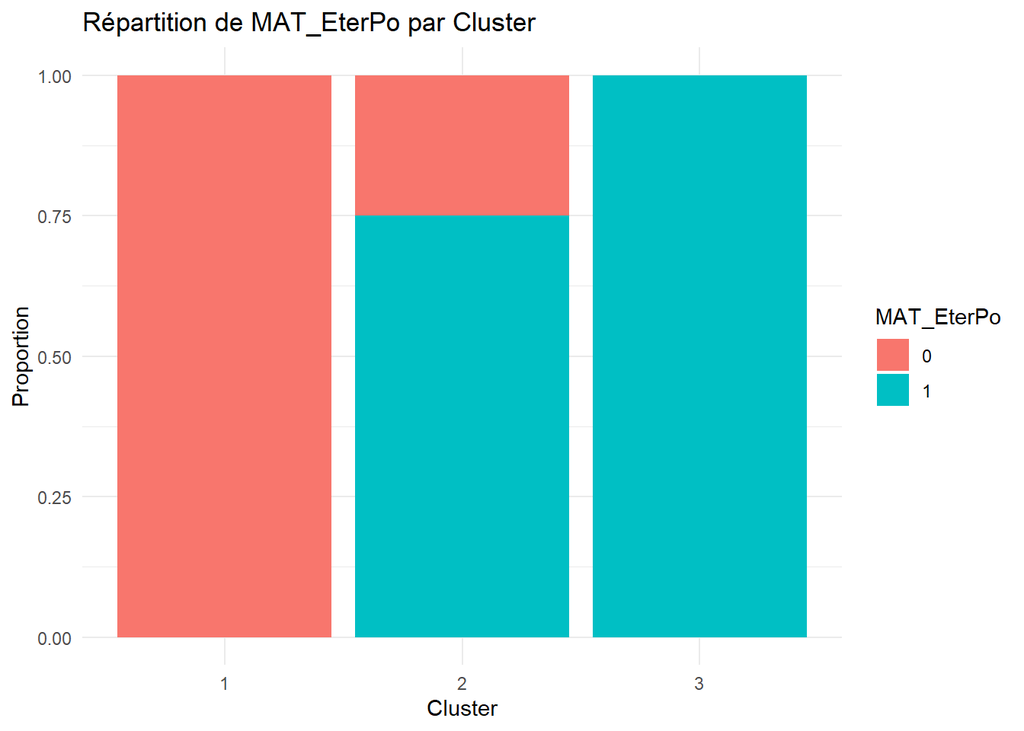

```r
library(ggplot2)
ggplot(data_a_expliquer, aes(x = clusters, fill = MAT_EterPo)) +
  geom_bar(position = "fill") +
  labs(
    title = "Répartition de MAT_EterPo par Cluster",
    x = "Cluster",
    y = "Proportion"
  ) +
  theme_minimal()
```

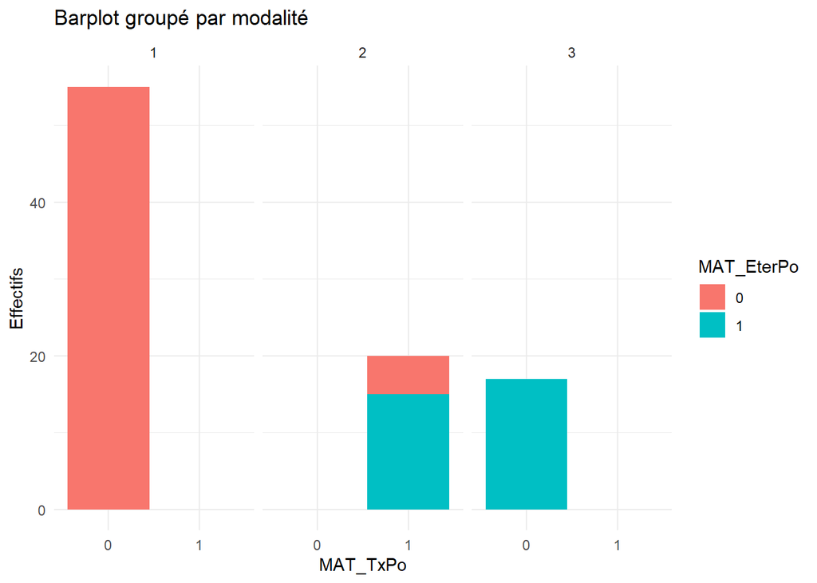

```r
##Visualisation des 2 variables sur les 3 clusters
ggplot(data_a_expliquer, aes(x = MAT_TxPo, fill = MAT_EterPo)) +
  geom_bar(position = "stack") +                    # Barres empilées
  facet_wrap(~clusters) +                           # Facet par clusters
  labs(
    title = "Barplot groupé par modalité",
    x = "MAT_TxPo",
    y = "Effectifs",
    fill = "MAT_EterPo"
  ) +
  theme_minimal()
```

##Caractérisation des clusters

Au regard de ce graphique, on peut dire que:

- Cluster 1: recense tous les élevages présents n’ont aucun cas pour les deux maladies respiratoires
- Cluster 2: compte tous les élevages présents ont des cas de toux et parmi eux, 75% présentent aussi des cas d’éternuement
- Cluster 3: arbore tous les élevages présents ont des cas d’éternuement

# Etape 3: Lien entre les variables retenues et la variable à expliquer

```r
##La variable de l'étape précédente
base3$groupe_respiratoire=as.factor(clusters)
```

## Lien avec les variables qualitatives: test du chi2 classic/chi2-exact

```r
var_qual=Filter(is.factor,base3)
effectif_theoriq_min=function(x){
  idx <- complete.cases(var_qual$groupe_respiratoire,x)
  tableau <- table(var_qual$groupe_respiratoire[idx],x[idx])
  expected <- outer(rowSums(tableau), colSums(tableau)) / sum(tableau)
  return (min(expected));
}
effectif_nij_min=sapply(var_qual,effectif_theoriq_min)
chi2_test=effectif_nij_min>=5
var_qual_test=data.frame(Variable=names(var_qual),effectif_nij_min=effectif_nij_min,chi2_test=chi2_test)
```

On pourra donc faire le test du chi2 pour 131 variables. Et pour le reste nous effectuerons un test de Fisher exact.

Nous effectuons donc ces tests ci-dessous

```r
test_res=function(x){
  idx <- complete.cases(var_qual[[x]],var_qual$groupe_respiratoire)
  test_value=ifelse(var_qual_test[x,"chi2_test"], chisq.test(var_qual[[x]][idx],var_qual$groupe_respiratoire[idx])$p.value,chisq.test(var_qual[[x]][idx],var_qual$groupe_respiratoire[idx],simulate.p.value=TRUE)$p.value)
  return(test_value);
}

var_qual_test$pvalue=sapply(var_qual_test$Variable,test_res)
var_qual_sig=var_qual_test[var_qual_test$pvalue<0.20,]$Variable
```

Il y donc 99 variables significatives.

Liste des variables qualitatives ayant un lien significatif avec la respiration

```r
var_qual_sig
```

```
##  [1] "X12x2_MAT1FRLAV_1"           "X12x2_MAT1FRLAV_2"
##  [3] "X20x1_NbIA_TR_1"             "X12x1_TRP_BAT_6_reg_rec"
##  [5] "X09x5_NbREP.JR_2"            "T07_VG_EauNbTr_NbT_2"
##  [7] "X09x3_MODE_DISTR_START"      "X12x1_TRP_BAT_2_reg_rec"
##  [9] "X20x1_CB_U_rec"              "X08_PARC_PA_3_reg_rec"
## [11] "X12x1_DesS_PExp_3_reg"       "X12x1_DesS_PExp_6_reg"
## [13] "X12x1_Des_BAT_6_reg_rec"     "X12x1_BLRACBD_3_reg"
## [15] "X17x3_TRBD.1NOUR_rec"        "X20x1_NTRDOS_2"
## [17] "X20x1_NbJr_PAS_1"            "T07_VG_SolProp"
## [19] "T07_VG_SolHumi"              "T07_VG_milieuDegrad"
## [21] "X13x4_Pail_Bio_rec"          "X17x3_PLSUPFE_rec"
## [23] "X06x1_gene_majo_1_rec"       "X03x2_OT_repro_1_rec"
## [25] "X15x1_NbVERM_synth_1"        "T01_T_EXT_1"
## [27] "MAT_TxPo"                    "MAT_EterPo"
## [29] "X20x2_ABB_VG"                "X20x2_ABB_Ve"
```

[output cut: 35 more lines]